# Etap V

Zofia Nawalany, Agata Gruszczyńska, Michał Karlicki

4 czerwca 2017

# Spis treści

1.Podsumowanie i wnioski  
2.Cel  
3.Efekt płci i kraju  
4.Efekt zadania i jego pozycji w kwestionariuszu  
5.Efekt kraju i języka  
6.Efekt wykształcenia ojca i matki  
7.Badanie istotności interakcji w modelu

# 1.Podsumowanie i wnioski

Zbadano interakcje między niektórymi elementami modelu. Okazało się, że interakcje występują między:  
-id zadania ~ pozycji w akruszu  
-kraj ~ płeć  
-wykształcenie matki ~ wykształcenie ojca  
Następnie zbadano istotność tych interakcji- wszystkie z powyższych okazały sie istotne. Na koniec porównano model stworzony w poprzednich etapach z modelem wzbogaconym o znalezione, istotne interakcje. Wynik testu anova wskazał wyższość modelu wzbogaconego o interakcje względem początkowego, bez interakcji.

# 2.Cel

Celem tego etapu projektu jest rozważenie i weryfikacja występowania interakcji (oraz ich istotności) pomiędzy kluczowymi elementami modelu. Przeanalizowano interakcje pomiędzy:  
- płcią a krajem  
- zadaniem a jego pozycją w kwestionariuszu  
- krajem a używanym przez ucznia językiem  
- wykształceniem matki a wykształceniem ojca

# 3.Efekt płci i kraju

Dla większości krajów średni czas rozwiązywania zadań wśród dziewcząt jest wyższy niż u chłopców. Wyjątkiem jest jednak Costa Rica oraz Mexico. Brak równoległości między odcinkami łamanych dla poszczególnych zadań wskazuje na występowanie interakcji.

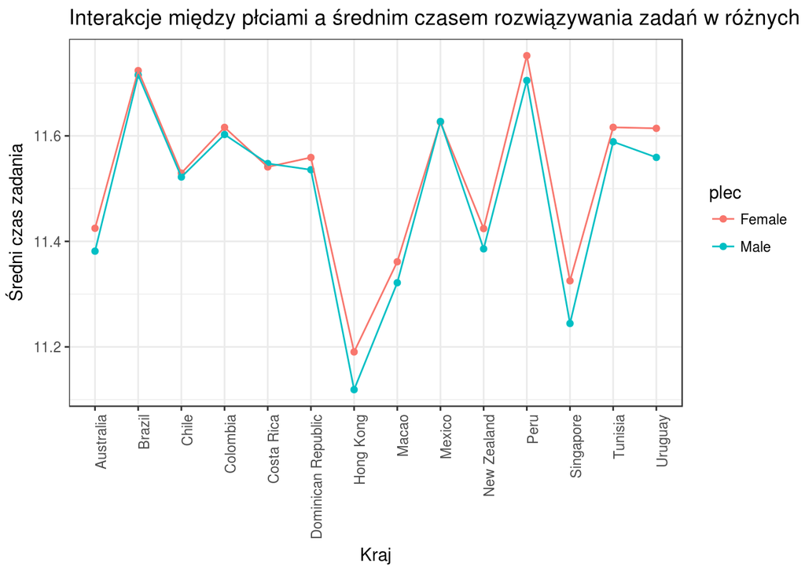

```r
int1 <- ddply(dane,.(kraj,plec),summarise, val = mean(log(question_time)))

ggplot(dane, aes(x = factor(kraj), y = log(question_time), colour = plec)) +
    geom_point(data = int1, aes(y = val)) +
    geom_line(data = int1, aes(y = val, group = plec)) +
    theme_bw()+
    theme(axis.text.x = element_text(angle = 90, hjust = 1))+
    xlab("Kraj")+
    ylab("Średni czas zadania")+
    ggtitle("Interakcje między płciami a średnim czasem rozwiązywania zadań w różnych krajach")
```

# 4.Efekt zadania i jego pozycji w kwestionariuszu

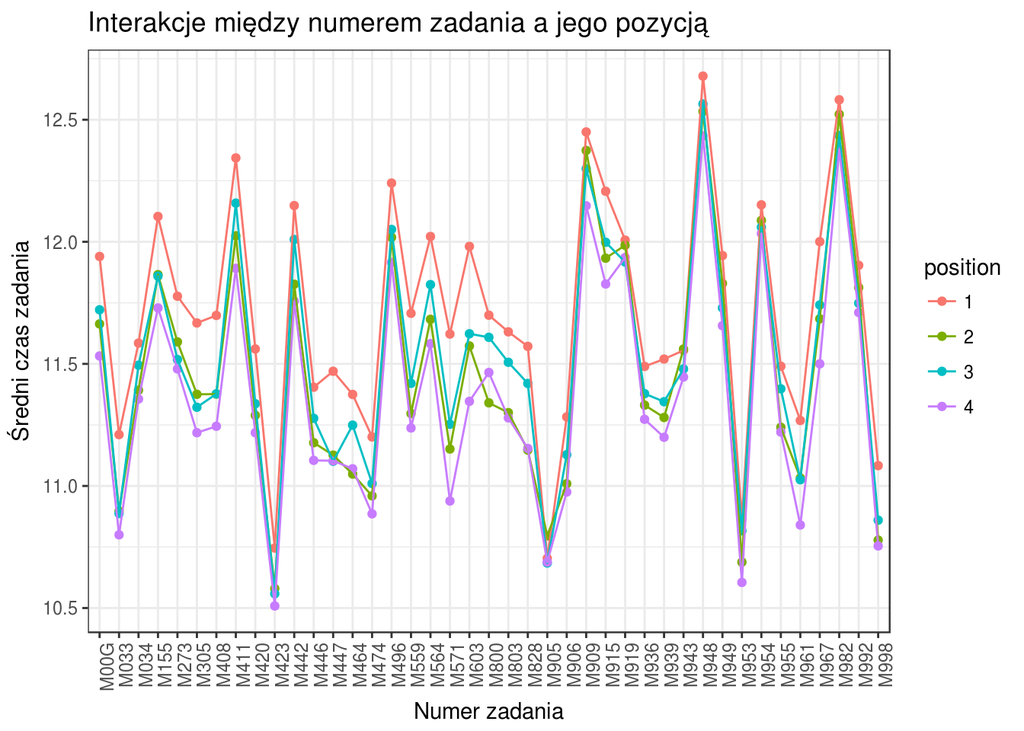

```r
int1 <- ddply(dane,.(item,position),summarise, val = mean(log(question_time)))

ggplot(dane, aes(x = factor(item), y = log(question_time), colour = position)) +
    geom_point(data = int1, aes(y = val)) +
    geom_line(data = int1, aes(y = val, group = position)) +
    theme_bw()+
    theme(axis.text.x = element_text(angle = 90, hjust = 1))+
    xlab("Numer zadania")+
    ylab("Średni czas zadania")+
    ggtitle("Interakcje między numerem zadania a jego pozycją")
```

# 5.Efekt kraju i języka

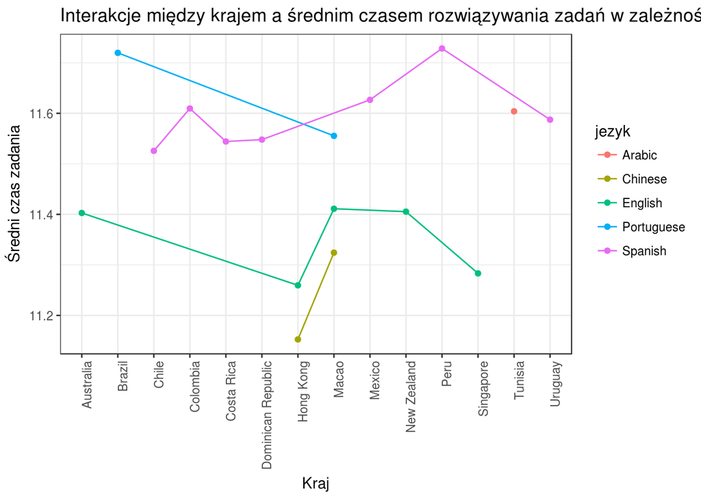

```r
int1 <- ddply(dane,.(kraj,jezyk),summarise, val = mean(log(question_time)))

ggplot(dane, aes(x = factor(kraj), y = log(question_time), colour = jezyk)) +
    geom_point(data = int1, aes(y = val)) +
    geom_line(data = int1, aes(y = val, group = jezyk)) +
    theme_bw()+
    theme(axis.text.x = element_text(angle = 90, hjust = 1))+
    xlab("Kraj")+
    ylab("Średni czas zadania")+
    ggtitle("Interakcje między krajem a średnim czasem rozwiązywania zadań w zależności od języka")
```

# 6.Efekt wykształcenia ojca i matki

Wykształcenie ojca na poziomie wyższym przekłada się na krótszy czas poświęcany na zadanie. Na wykresie widoczne jest przecięcie, co oznacza interakcję pomiędzy wykształceniem ojca i matki.

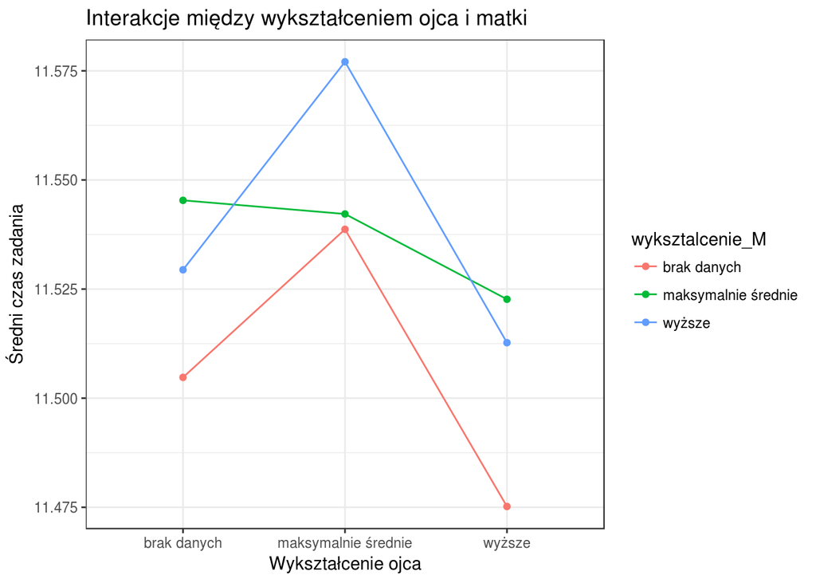

```r
int1 <- ddply(dane,.(wyksztalcenie_O,wyksztalcenie_M),summarise, val = mean(log(as.numeric(question_time))))

ggplot(dane, aes(x = factor(wyksztalcenie_O), y = log(question_time), colour = wyksztalcenie_M)) +
    geom_point(data = int1, aes(y = val)) +
    geom_line(data = int1, aes(y = val, group = wyksztalcenie_M)) +
    theme_bw()+
    theme(axis.text.x = element_text(angle = 0, hjust = 0.5))+
    xlab("Wykształcenie ojca")+
    ylab("Średni czas zadania")+
    ggtitle("Interakcje między wykształceniem ojca i matki")
```

# 7. Badanie istotności interakcji w modelu

W celu zbadania istotności znalezionych powyżej interakcji, modyfikujemy nasz model z poprzednich etapów.  
Znalezione interakcje to:  
-id zadania ~ pozycji w akruszu  
-kraj ~ płeć  
-wykształcenie matki ~ wykształcenie ojca

Najpierw sprawdzono istotność każdej z tych interkacji testem anova- wszystkie wykazały wysoką istotność.

```r
model_podstawowy<-(lm(log(question_time)~(position/item)+jezyk+kraj+plec+wyksztalcenie_M+wyksztalcenie_O+czytanieCzasopismNaukowych, data=dane))

anova(lm(log(question_time)~item*position, data=dane))
```

```
## Analysis of Variance Table
##
## Response: log(question_time)
##                   Df Sum Sq Mean Sq F value    Pr(>F)
## item              40  94318 2357.94 5297.52 < 2.2e-16 ***
## position           3   7710 2569.96 5773.85 < 2.2e-16 ***
## item:position    120   1559   12.99   29.18 < 2.2e-16 ***
## Residuals     467394 208039    0.45
## ---
## Signif. codes:  0 '***' 0.001 '**' 0.01 '*' 0.05 '.' 0.1 ' ' 1
```

```r
anova(lm(log(question_time)~(item/position), data=dane))
```

```
## Analysis of Variance Table
##
## Response: log(question_time)
##                   Df Sum Sq Mean Sq F value    Pr(>F)
## item              40  94318 2357.94 5297.52 < 2.2e-16 ***
## item:position    123   9268   75.35  169.29 < 2.2e-16 ***
## Residuals     467394 208039    0.45
## ---
## Signif. codes:  0 '***' 0.001 '**' 0.01 '*' 0.05 '.' 0.1 ' ' 1
```

```r
anova(lm(log(question_time)~(kraj*plec), data=dane))
```

```
## Analysis of Variance Table
##
## Response: log(question_time)
##               Df Sum Sq Mean Sq   F value    Pr(>F)
## kraj          13  11902  915.55 1428.9271 < 2.2e-16 ***
## plec           1     93   93.26  145.5549 < 2.2e-16 ***
## kraj:plec     13     70    5.37    8.3849 < 2.2e-16 ***
## Residuals 467530 299559    0.64
## ---
## Signif. codes:  0 '***' 0.001 '**' 0.01 '*' 0.05 '.' 0.1 ' ' 1
```

```r
anova(lm(log(question_time)~(wyksztalcenie_M*wyksztalcenie_O), data=dane))
```

```
## Analysis of Variance Table
##
## Response: log(question_time)
##                                     Df Sum Sq Mean Sq F value    Pr(>F)
## wyksztalcenie_M                      2     71  35.639 53.4922 < 2.2e-16
## wyksztalcenie_O                      2     29  14.612 21.9316  2.99e-10
## wyksztalcenie_M:wyksztalcenie_O      4     21   5.364  8.0506  1.74e-06
## Residuals                       467549 311503   0.666
##
## wyksztalcenie_M                 ***
## wyksztalcenie_O                 ***
## wyksztalcenie_M:wyksztalcenie_O ***
## Residuals
## ---
## Signif. codes:  0 '***' 0.001 '**' 0.01 '*' 0.05 '.' 0.1 ' ' 1
```

Następnie porównano model stworzony w poprzednich etapach projektu (model_podstawowy) z modelem wzbogaconym o znalezione interakcje (model_nowy). Na podstawie wyników testu anova można stwierdzić, że model wzbogacony o interakcje jest istotnie lepszy niż poprzedni model.

```r
model_nowy<-(lm(log(question_time)~position*item+jezyk+kraj*plec+wyksztalcenie_M*wyksztalcenie_O+czytanieCzasopismNaukowych, data=dane))

anova(model_podstawowy, model_nowy)
```

```
## Analysis of Variance Table
##
## Model 1: log(question_time) ~ (position/item) + jezyk + kraj + plec +
##     wyksztalcenie_M + wyksztalcenie_O + czytanieCzasopismNaukowych
## Model 2: log(question_time) ~ position * item + jezyk + kraj * plec +
##     wyksztalcenie_M * wyksztalcenie_O + czytanieCzasopismNaukowych
##   Res.Df    RSS Df Sum of Sq      F    Pr(>F)
## 1 437678 183784
## 2 437661 183717 17    67.377 9.4418 < 2.2e-16 ***
## ---
## Signif. codes:  0 '***' 0.001 '**' 0.01 '*' 0.05 '.' 0.1 ' ' 1
```